# Penentuan Orde (p,d,q) untuk Setiap Pendugaan Parameter Model

Andi Indra Jaya

2024-04-18

### Latihan 1

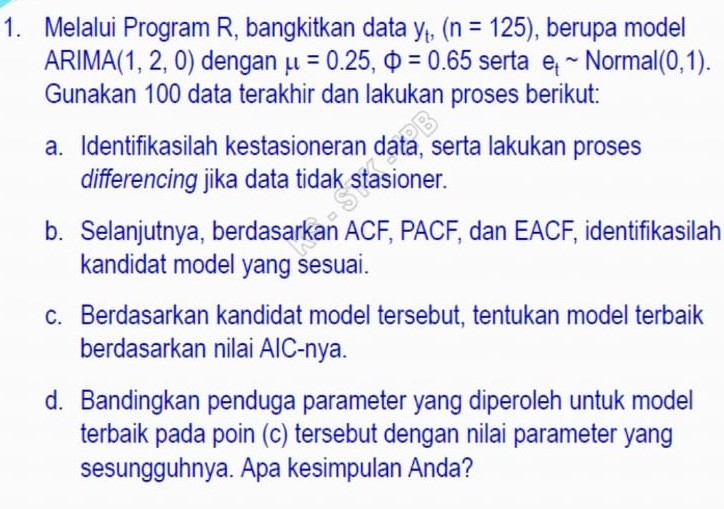

#### a. identifikasi kestasioneran data & proses differencing

```r
# parameter untuk model ARIMA
n = 125     # number of data points
mu = 0.25
phi = 0.65
sigma = 1

# membangkitkan white noise
set.seed(999)
e = rnorm(n, mean = 0, sd = sigma)

# Generate ARIMA(1, 2, 0) process with specified parameters
arima_sim = arima.sim(model = list(ar = phi, order = c(1, 2, 0)), n = n, sd = sqrt(mu))

# Use the last 100 data points for analysis
data_analyze <- tail(arima_sim, 100)
round(data_analyze,2)
```

```
## Time Series:
## Start = 28
## End = 127
## Frequency = 1
##   [1] 185.15 197.42 210.56 223.95 237.43 250.66 263.58 276.40 289.27 302.18
##  [11] 315.02 327.16 339.05 350.18 360.92 371.05 381.02 391.29 402.11 413.03
##  [21] 424.25 434.73 444.70 454.57 464.25 473.60 483.16 492.77 502.33 511.40
##  [31] 520.38 529.51 538.24 546.30 553.95 560.59 567.35 574.37 581.81 589.97
##  [41] 598.99 608.63 618.32 628.25 637.98 648.35 659.03 670.06 680.37 689.25
##  [51] 697.51 704.78 711.53 717.60 723.44 729.49 735.12 740.04 744.29 748.63
##  [61] 751.92 755.28 759.42 763.56 768.29 773.82 779.90 786.66 794.11 801.24
##  [71] 808.55 815.39 822.00 827.69 831.81 834.60 836.99 839.98 844.47 850.36
##  [81] 856.67 863.38 870.81 878.32 884.58 890.15 895.47 899.74 902.44 904.13
##  [91] 904.16 903.52 901.98 899.52 896.01 891.31 885.72 880.14 874.56 868.92
```

#### Uji Augmented Dickey-Fuller

Uji Augmented Dickey-Fuller digunakan untuk memeriksa stasioneritas suatu dataset.

```r
# Inisialisasi penghitung untuk differencing
differences = 0

# Fungsi untuk menerapkan diferensiasi secara rekursif dan menguji stasioneritas
test_stationarity = function(data){
  library(tseries)
  adf.test = adf.test(data)

  if(adf.test$p.value > 0.05){
    # data tidak staioner, maka lakukan differencing
    differences <<- differences + 1
    differenced_data = diff(data)
    return(test_stationarity(differenced_data))
  } else {
    # data stasioner, maka tampilkan hasil dan data
    list(stationarity_test = adf.test,
         times_differenced = differences)
    }
}

# Jalankan fungsi test_stationarity
stationarity_results = test_stationarity(data_analyze)
print(stationarity_results)
```

```
## $stationarity_test
##
##  Augmented Dickey-Fuller Test
##
## data:  data
## Dickey-Fuller = -4.1436, Lag order = 4, p-value = 0.01
## alternative hypothesis: stationary
##
##
## $times_differenced
## [1] 2
```

Berdasarkan Uji Augmented Fuller, kita dapat memenuhi kriteria stasioneritas suatu data ketika sudah dilakukan differencing 2 kali dengan p-value yang diperoleh < 0.01.

#### b. Identifikasi Kandidat Model dengan ACF, PACF, dan EACF

#### Membuat Plot ACF & PACF

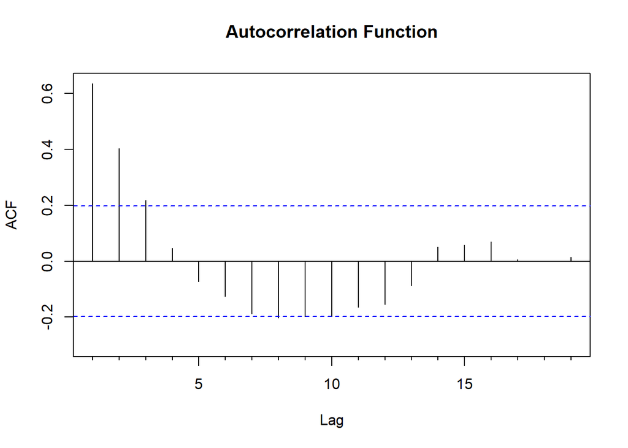

```r
library(forecast)

# Menggunakan data time series yang stasioner
data_diff = diff(data_analyze, differences = 2)

# Plot ACF
Acf(data_diff, main='Autocorrelation Function')
```

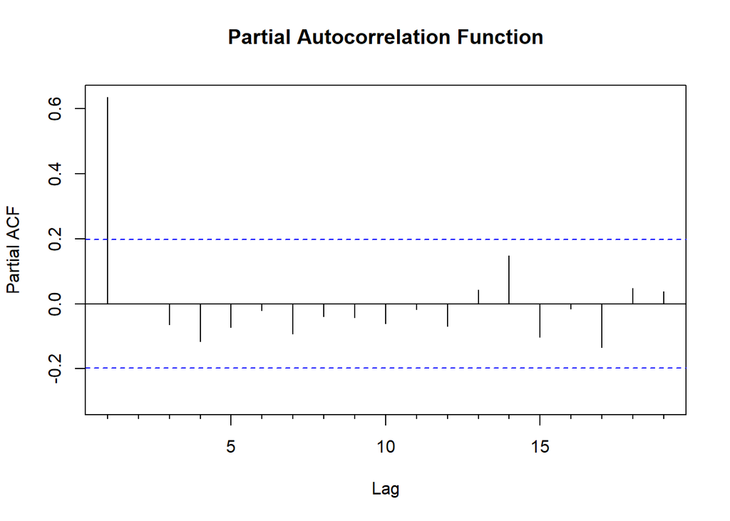

```r
# Plot PACF
Pacf(data_diff, main='Partial Autocorrelation Function')
```

#### Membuat plot EACF untuk penentuan model dugaan

Plot EACF cukup efisien untuk mengukur signifikansi autokorelasi dalam mengidentifikasi orde AR dan MA dalam model ARIMA, terutama ketika pola pada plot ACF dan PACF yang tidak jelas. Plot EACF diberikan sebagai berikut:

```r
# Inisialisasi TSA package for EACF
library(TSA)
# Plot EACF
eacf(data_diff)
```

```
## AR/MA
##   0 1 2 3 4 5 6 7 8 9 10 11 12 13
## 0 x x x o o o o o o o o  o  o  o
## 1 o o o o o o o o o o o  o  o  o
## 2 o o o o o o o o o o o  o  o  o
## 3 x o o o o o o o o o o  o  o  o
## 4 x x x o o o o o o o o  o  o  o
## 5 o x x o o o o o o o o  o  o  o
## 6 o x x x o o o o o o o  o  o  o
## 7 x x x o o o o o o o o  o  o  o
```

Dalam matriks EACF, simbol (`x`) biasanya menandakan nilai yang signifikan dan simbol (`o`) menandakan nilai yang tidak signifikan. Dalam tabel EACF di atas, kita dapat menentukan model ARIMA sebagai berikut:

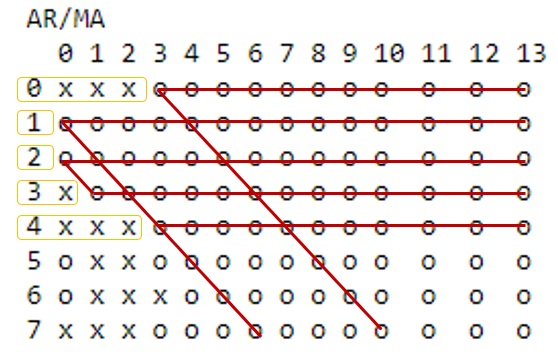

Berdasarkan hasil plot EACF di atas, diperoleh 5 model dugaan yang dapat diduga sebagai model tentatif yaitu

- Baris 1: ARIMA (0,2,3)
- Baris 2: ARIMA (1,2,0)
- Baris 3: ARIMA (2,2,0)
- Baris 4: ARIMA (3,2,1)
- Baris 5: ARIMA (4,2,3)

#### c. Pemilihan Model Terbaik dengan Nilai AIC

```r
# pemodelan ARIMA akan menggunakan data original tanpa differencing
fits = list(
  model1 = Arima(data_analyze, order = c(0,2,3)),
  model2 = Arima(data_analyze, order = c(1,2,0)),
  model3 = Arima(data_analyze, order = c(2,2,0)),
  model4 = Arima(data_analyze, order = c(3,2,1)),
  model5 = Arima(data_analyze, order = c(4,2,3))
)

aic_values = sapply(fits, AIC)
round(aic_values,2)
```

```
## model1 model2 model3 model4 model5
## 152.45 146.96 148.95 151.30 156.81
```

#### d. Membandingkan penduga parameter untuk model terbaik pada poin (c) dengan nilai parameter sesungguhnya

```r
print(fits$model2)
```

```
## Series: data_analyze
## ARIMA(1,2,0)
##
## Coefficients:
##          ar1
##       0.6705
## s.e.  0.0745
##
## sigma^2 = 0.2534:  log likelihood = -71.48
## AIC=146.96   AICc=147.08   BIC=152.13
```

Penduga parameter model yang diperoleh pada poin (c) tidak jauh berbeda dengan nilai parameter sesungguhnya karena model terbaik yang diperoleh memiliki orde ARIMA yang sama dengan nilai parameter model sesungguhnya yaitu ARIMA (1,2,0). Adapun nilai penduga paramater model diperoleh sebesar 0.671 sementara penduga parameter sebenarnya yaitu 0.65.

### Latihan 2

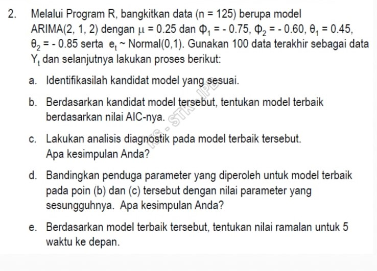

#### a. Identifikasi Kandidat Model yang Sesuai

```r
# parameter untuk model ARIMA
n = 125     # number of data points
mu = 0.25
sigma = 1
phi = c(-0.75, -0.60)
theta = c(0.45, -0.85)

# membangkitkan white noise
set.seed(999)
e = rnorm(n, mean = 0, sd = sigma)

library(forecast)
# Simulasi model ARIMA(2,1,2)
arima_sim2 = arima.sim(n = n, model = list(ar = phi, ma = theta,
                                           order = c(2,1,2)), sd = sigma) + mu

# Mengambil 100 data terakhir untuk analisis
data_analyze2 <- tail(arima_sim2, 100)
round(data_analyze2,2)
```

```
## Time Series:
## Start = 27
## End = 126
## Frequency = 1
##   [1]  0.81 -0.46  0.69  0.58  1.59  1.55  0.11  0.85 -0.07 -1.09  2.20  0.38
##  [13] -1.14  1.95  1.11 -1.08  0.22  0.77  0.97 -0.74 -1.18  0.71 -1.20 -0.10
##  [25]  2.57 -0.73  0.93  2.44  0.00 -0.35  1.35  0.32  0.98  2.21 -0.25 -0.71
##  [37] -1.92  0.61  0.18 -1.79  0.37 -0.20  0.46 -0.85 -2.26 -0.28  0.67 -2.59
##  [49] -1.11  3.74 -2.40 -1.22  3.80 -1.25 -0.48  2.68 -2.03 -0.70  1.60 -1.95
##  [61] -1.16 -2.39 -2.10  0.71  1.06  1.36  1.33 -1.36 -0.23  2.46 -0.88 -3.72
##  [73]  0.17  1.68 -3.60 -3.46  0.34 -3.08 -2.90  0.15 -4.02 -3.13 -2.15 -3.38
##  [85] -1.07 -1.36 -3.66 -2.97 -2.75 -3.65 -3.07 -2.15 -3.00 -2.86 -4.17 -3.91
##  [97] -2.37 -1.20 -3.01 -2.10
```

```r
# Inisialisasi penghitung untuk differencing
differences = 0
test_stationarity(data_analyze2)
```

```
## $stationarity_test
##
##  Augmented Dickey-Fuller Test
##
## data:  data
## Dickey-Fuller = -5.9827, Lag order = 4, p-value = 0.01
## alternative hypothesis: stationary
##
##
## $times_differenced
## [1] 1
```

#### Membuat plot EACF untuk penentuan model dugaan

```r
# Menggunakan data time series yang stasioner
data_diff1 = diff(data_analyze, differences = 1)

library(TSA)
eacf(data_diff1)
```

[output not shown]

#### **b. Pemilihan Model Terbaik dengan Nilai AIC**

```r
# pemodelan ARIMA akan menggunakan data original tanpa differencing
fits = list(
  model1 = Arima(data_analyze2, order = c(0,1,6)),
  model2 = Arima(data_analyze2, order = c(1,1,6)),
  model3 = Arima(data_analyze2, order = c(2,1,2)),
  model4 = Arima(data_analyze2, order = c(3,1,2)),
  model5 = Arima(data_analyze2, order = c(4,1,2)),
  model6 = Arima(data_analyze2, order = c(5,1,4))

)

aic_values = sapply(fits, AIC)
round(aic_values,2)
```

```
## model1 model2 model3 model4 model5 model6
## 336.67 337.50 329.57 330.91 332.70 334.10
```

Model terbaik yaitu model3 dengan ARIMA (2,1,2)

#### d. Analisis Diagnostik Model Terbaik

- Pemeriksaan Residu

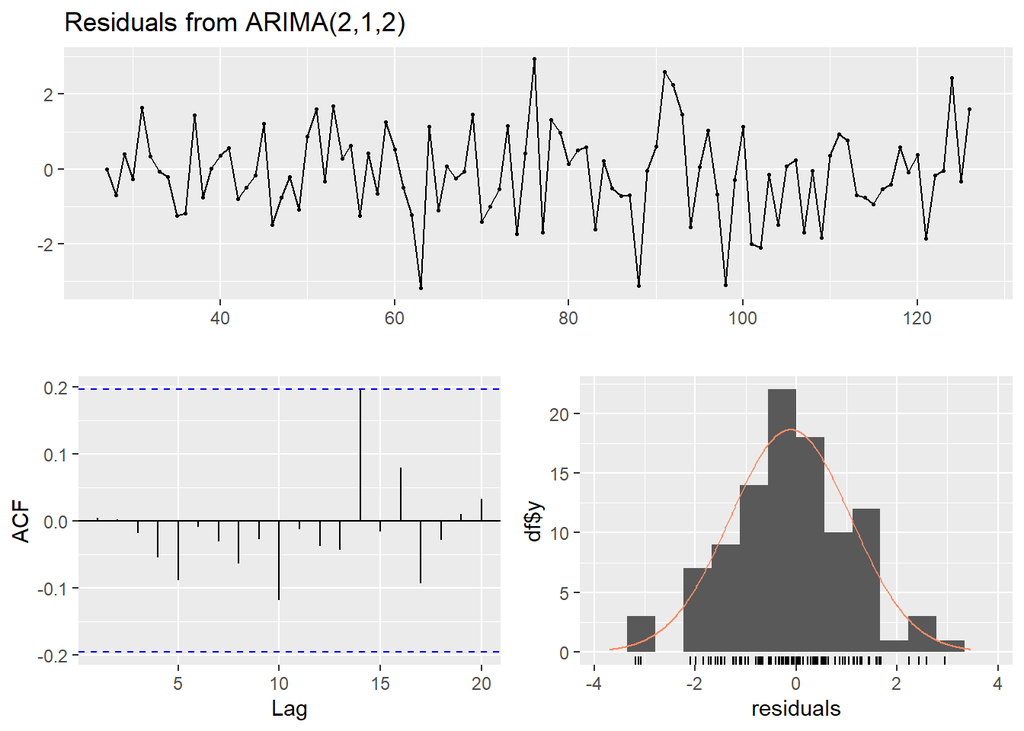

  ```
  ##
  ##  Ljung-Box test
  ##
  ## data:  Residuals from ARIMA(2,1,2)
  ## Q* = 3.4334, df = 6, p-value = 0.7528
  ##
  ## Model df: 4.   Total lags used: 10
  ```

  ```r
  checkresiduals(fits$model3)
  ```

  p–value Ljung-Box (0.752) > alpha(0.05), sehingga tidak ada bukti signifikan autokorelasi dalam residu.
- Normalitas Residu

  ```r
  shapiro.test(residuals(fits$model3))
  ```

  ```
  ##
  ##  Shapiro-Wilk normality test
  ##
  ## data:  residuals(fits$model3)
  ## W = 0.99087, p-value = 0.7346
  ```

#### d. Membandingkan penduga parameter untuk model terbaik pada poin (c) dengan nilai parameter sesungguhnya

```r
print(fits$model3)
```

```
## Series: data_analyze2
## ARIMA(2,1,2)
##
## Coefficients:
##           ar1      ar2     ma1      ma2
##       -0.7763  -0.6289  0.1574  -0.5348
## s.e.   0.0916   0.0914  0.1136   0.1180
##
## sigma^2 = 1.497:  log likelihood = -159.78
## AIC=329.57   AICc=330.22   BIC=342.55
```

Penduga parameter model yang diperoleh pada poin (c) dengan model ARIMA (2,1,2) diberikan sebagai berikut:  
AR<sub>1</sub>= -0.776; AR<sub>2</sub> = -0.629  
MA<sub>1</sub>= 0.157; MA<sub>2</sub> = -0.534

#### e. Nilai Ramalan untuk 5 waktu ke depan

```r
library(forecast)
ramalan = forecast(fits$model3, h=5)

# Tampilkan nilai peramalan
print(ramalan)
```

```
##     Point Forecast     Lo 80      Hi 80     Lo 95      Hi 95
## 127      -1.239825 -2.808066  0.3284163 -3.638243  1.1585931
## 128      -3.330053 -5.008280 -1.6518262 -5.896679 -0.7634267
## 129      -2.250253 -3.994119 -0.5063880 -4.917265  0.4167585
## 130      -1.773911 -3.768628  0.2208065 -4.824567  1.2767460
## 131      -2.822852 -4.884881 -0.7608226 -5.976453  0.3307496
```

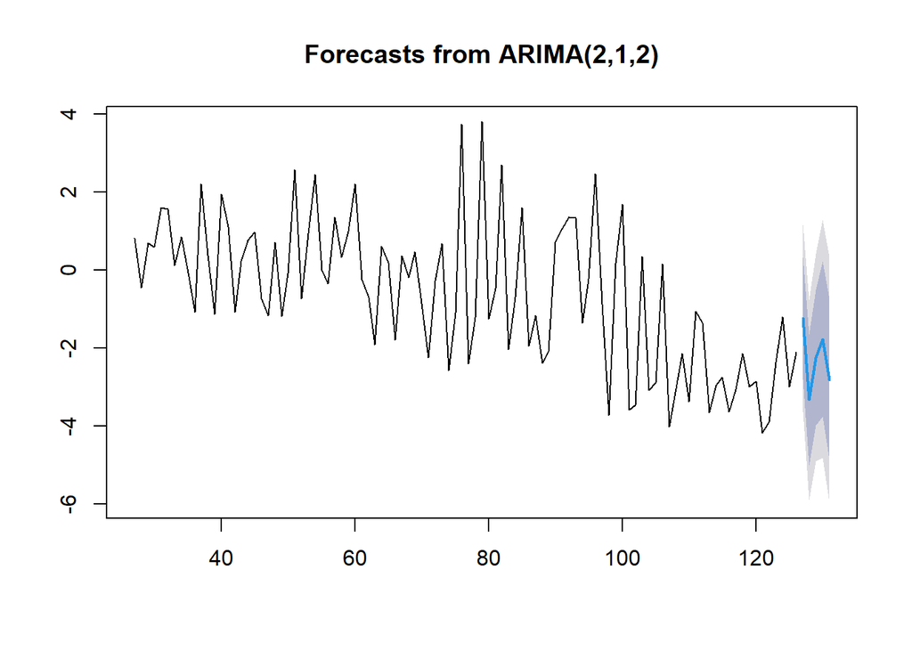

```r
# Plot peramalan untuk visualisasi
plot(ramalan)
```